# Wildfire Data

Laina Cleaton

2025-10-26

```r
library(tidyverse)
evac_zone_status <- read_csv("evac_zone_status_geo_event_map.csv")
evac_zones <- read_csv("evac_zones_gis_evaczone.csv")
geo_events <- read_csv("geo_events_geoevent.csv")
view(evac_zone_status)
```

```r
view(evac_zones)
```

```r
view(geo_events)
```

In order to conduct a temporal and spatial analysis, we will join the **evac_zone_status**, **geo_events**, and **evac_zones** datasets. The ‘changelog’ datasets are unnecessary for the analysis.

The first join, **evac_zone_status** and **geo_events** (by geo_event_id), is important because **evac_zone_status** does not include information on the wildfire (name, geographical location, etc.). **evac_zone_status** only tracks the evacuation zone’s activity over time, so by joining these two tables, we will be able to see the evacuation status changes associated with a specific wildfire.

The second join, **evac_zone_status** and **evac_zones** (by uid_v2), brings in the spatial component. Each evacuation zone’s geometry and display name will be attached to its status updates, which means we’ll be able to pinpoint the when and where each evacuation occurred. Evacuation boundaries can be visualized, their areas calculated, and they can be overlayed with demographic data.

Altogether, the “core spatial dataset” brings together the components of the who, when, and where of wildfire evacuations; which fire the evacuations were associated with, when they were created, and where they occurred.

```r
install.packages("sf")
```

```r
library(sf)
```

```r
# --- Convert CSVs to sf objects using WKT column ---
# evac_zones
evac_zones <- st_as_sf(evac_zones, wkt = "geom", crs = 4326)

# select evac_zone_status columns
evac_zone_status_sel <- evac_zone_status %>%
  rename(status_date = date_created) %>%
  select(uid_v2, geo_event_id, status_date)

# select geo_events columns
geo_events_sel <- geo_events %>%
  rename(geo_event_id = id) %>%
  select(geo_event_id, name, lat, lng)

# select evac_zones columns
evac_zones_sel <- evac_zones %>%
  rename(geom_evac_zone = geom) %>%
  select(uid_v2, display_name, geom_evac_zone)

#join columns
core_wildfire_dataset <- evac_zone_status_sel %>%
  left_join(geo_events_sel, by = "geo_event_id") %>%
  left_join(evac_zones_sel, by = "uid_v2") %>%
  st_as_sf()
```

We cannot use rows with NA in **display_name** because they lack geometry, and could break spatial joins. Therefore, we can filter these NA’s out.

```r
core_wildfire_geo <- core_wildfire_dataset %>%
  filter(!is.na(display_name))
```

After joining the selected WatchDuty tables into a single dataset, each record now represents a single evacuation status update. This means that there can be multiple entries per evacuation zone, **uid_v2**, as its status changes over time. Thus we will need to summarize those updates into meaningful evacuation timelines:

```
1. Evacuation start time: the earliest status_date recorded for that zone.
2. Evacuation end time: the latest status_date recorded.
3. Evacuation duration: the time difference between those two points.
```

```r
evac_timeline <- core_wildfire_geo %>%
  st_drop_geometry() %>%
  group_by(uid_v2) %>%
  summarise(
    n_updates = n(),
    min_date = min(status_date),
    max_date = max(status_date),
    diff_hours = as.numeric(difftime(max_date, min_date, units = "hours"))
  ) %>%
  arrange(desc(diff_hours))
```

Now I need to check the validity of my geom polygons, to ensure I can filter the data and visualize the results.

```r
library(sf)

# Convert the CSV with WKT geometry to sf safely
evac_zones_sf <- st_as_sf(evac_zones, wkt = "geom", crs = 4326, quiet = TRUE)

# Rename geometry column for clarity
evac_zones_sf <- evac_zones_sf %>%
  rename(geometry = geom)

# Fix invalid polygons
evac_zones_sf <- st_make_valid(evac_zones_sf)

# Drop empty geometries
evac_zones_sf <- evac_zones_sf %>%
  filter(!st_is_empty(geometry))

# Check
print(st_is_valid(evac_zones_sf) %>% table())
```

```
## .
## FALSE  TRUE
##   134 37324
```

I have 37324 valid geometries, and 134 invalid geometries, even after conversion. Now I can filter out those invalid geometries.

```r
evac_zones_sf <- evac_zones_sf %>%
  filter(st_is_valid(geometry))
```

```r
evac_zone_status_sel <- evac_zone_status %>%
  rename(status_date = date_created) %>%
  select(uid_v2, geo_event_id, status_date)

geo_events_sel <- geo_events %>%
  rename(geo_event_id = id) %>%
  select(geo_event_id, name, lat, lng)

evac_zones_sel <- evac_zones_sf %>%
  select(uid_v2, display_name, geometry)

core_wildfire_geo <- evac_zone_status_sel %>%
  left_join(geo_events_sel, by = "geo_event_id") %>%
  left_join(evac_zones_sel, by = "uid_v2") %>%
  st_as_sf()
```

Next, I wanted to see the distribution of the proportion of all the WatchDuty wildfires. I wanted to see which duration times made up the majority of these evacuations.

```r
evac_timeline <- evac_timeline %>%
  mutate(diff_hours = as.numeric(diff_hours)) %>%
  filter(!is.na(diff_hours), diff_hours > 0)
```

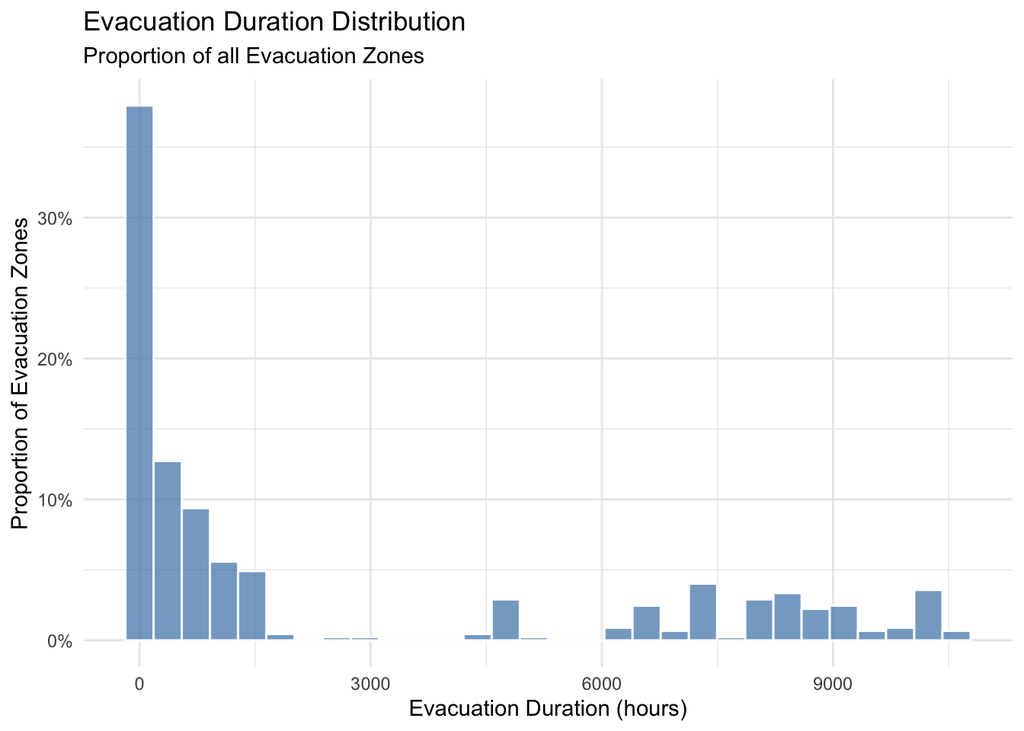

```r
library(tidyverse)
ggplot(evac_timeline, aes(x = diff_hours)) +
  geom_histogram(
    aes(y = after_stat(count / sum(count))),
    bins = 30,
    fill = "steelblue",
    color = "white",
    alpha = 0.7) +
  labs(
    title = "Evacuation Duration Distribution",
    subtitle = "Proportion of all Evacuation Zones",
    x = "Evacuation Duration (hours)",
    y = "Proportion of Evacuation Zones"
  ) +
  scale_y_continuous(labels = scales::percent_format()) +
  theme_minimal()
```

```r
library(sf)

ca_bbox <- st_sfc(
  st_polygon(list(rbind(
    c(-125, 32),
    c(-125, 42),
    c(-114, 42),
    c(-114, 32),
    c(-125, 32)
  ))),
  crs = st_crs(core_wildfire_geo)
)

cali_wildfire_geo <- core_wildfire_geo[st_intersects(core_wildfire_geo, ca_bbox, sparse = FALSE), ]
```

```r
library(scales)
evac_timeline <- evac_timeline %>%
  mutate(diff_hours = as.numeric(diff_hours)) %>%
  filter(!is.na(diff_hours), diff_hours > 0)

cali_evac_timeline <- cali_wildfire_geo %>%
  st_drop_geometry() %>%
  group_by(uid_v2) %>%
  summarise(
    n_updates = n(),
    min_date = min(status_date),
    max_date = max(status_date),
    diff_hours = as.numeric(difftime(max_date, min_date, units = "hours"))
  ) %>%
  filter(!is.na(diff_hours), diff_hours > 0)

cali_evac_timeline %>%
  summarise(
    n_zones = n(),
    mean_duration = mean(diff_hours, na.rm = TRUE),
    median_duration = median(diff_hours, na.rm = TRUE),
    sd_duration = sd(diff_hours, na.rm = TRUE),
    min_duration = min(diff_hours, na.rm = TRUE),
    max_duration = max(diff_hours, na.rm = TRUE),
    p25 = quantile(diff_hours, 0.25, na.rm = TRUE),
    p75 = quantile(diff_hours, 0.75, na.rm = TRUE)
  )
```

```
## # A tibble: 1 × 8
##   n_zones mean_duration median_duration sd_duration min_duration max_duration
##     <int>         <dbl>           <dbl>       <dbl>        <dbl>        <dbl>
## 1     222         4523.           4731.       3896.      0.00354       10602.
## # ℹ 2 more variables: p25 <dbl>, p75 <dbl>
```

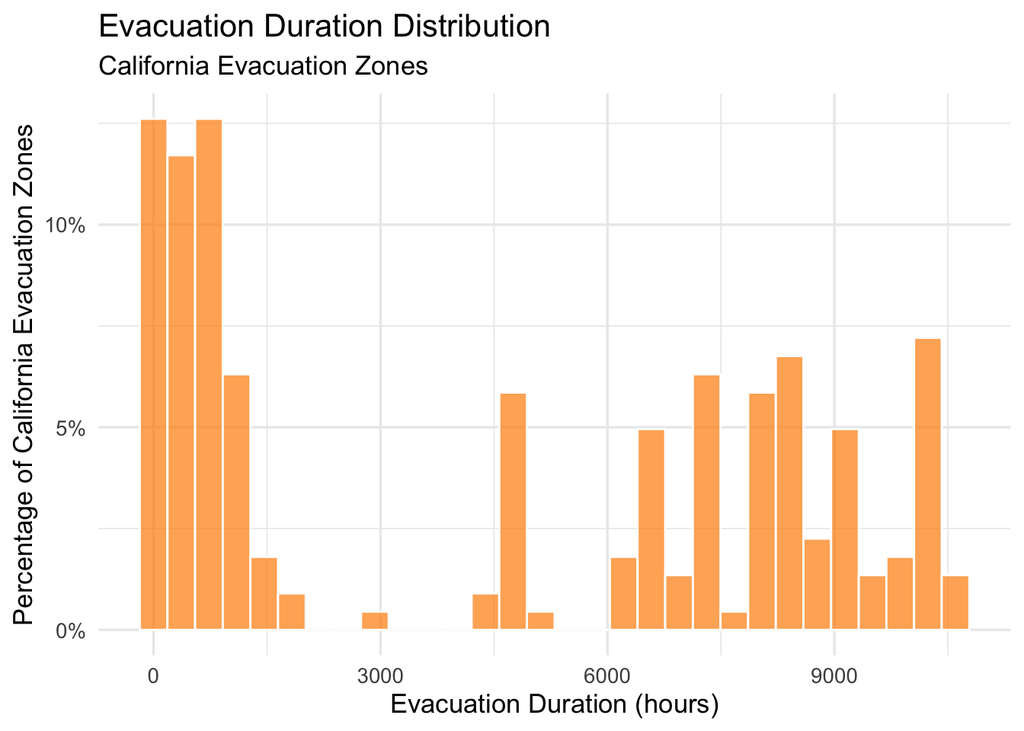

```r
ggplot(cali_evac_timeline, aes(x = diff_hours)) +
  geom_histogram(
    aes(y = after_stat(count / sum(count))),   # convert counts to proportions
    bins = 30,
    fill = "darkorange",
    color = "white",
    alpha = 0.7
  ) +
  labs(
    title = "Evacuation Duration Distribution",
    subtitle = "California Evacuation Zones",
    x = "Evacuation Duration (hours)",
    y = "Percentage of California Evacuation Zones"
  ) +
  scale_y_continuous(labels = percent_format()) +
  theme_minimal(base_size = 13)
```

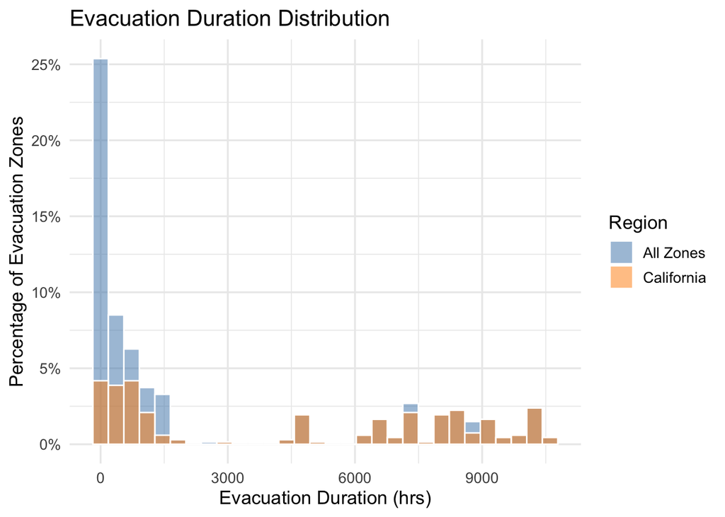

```r
library(scales)

evac_timeline <- evac_timeline %>%
  mutate(diff_hours = as.numeric(diff_hours)) %>%
  filter(!is.na(diff_hours), diff_hours > 0)

evac_timeline_full <- evac_timeline %>%
  mutate(region = "All Zones") %>%
  bind_rows(
    cali_evac_timeline %>%
      mutate(region = "California")
  )

ggplot(evac_timeline_full, aes(x = diff_hours, fill = region)) +
  geom_histogram(
    aes(y = after_stat(count / sum(count))),
    bins = 30,
    alpha = 0.5,   # transparency so both histograms are visible
    position = "identity",  # overlay instead of stacked
    color = "white"
  ) +
  scale_fill_manual(values = c("All Zones" = "steelblue", "California" = "darkorange")) +
  labs(
    title = "Evacuation Duration Distribution",
    subtitile = "In the United States",
    x = "Evacuation Duration (hrs)",
    y = "Percentage of Evacuation Zones",
    fill = "Region"
  ) +
  scale_y_continuous(labels = percent_format()) +
  theme_minimal(base_size = 13)
```

Next, we can visualize the joined dataset, using leaflet. Although California is my place of interest, I was curious about where other fires were located.

```r
install.packages("leaflet")
```

```r
library(leaflet)

leaflet(filter(core_wildfire_geo, name %in% top_fires)) %>%
  addProviderTiles(providers$CartoDB.Positron) %>%
  addPolygons(
    fillColor = ~factor(name),
    color = "#444",
    weight = 1,
    popup = ~paste("<b>Fire:</b>", name, "<br><b>Zone:</b>", display_name)
  )
```

Next I wanted to observe the distribution of evacuation durations as a heatmap.

```r
core_wildfire_geo_time <- core_wildfire_geo %>%
  left_join(evac_timeline %>% select(uid_v2, diff_hours), by = "uid_v2") %>%
  filter(!is.na(diff_hours))
```

```r
library(leaflet)

pal <- colorNumeric(
  palette = "YlOrRd",
  domain = core_wildfire_geo_time$diff_hours
)

leaflet(core_wildfire_geo_time) %>%
  addProviderTiles(providers$CartoDB.Positron) %>%
  addPolygons(
    fillColor = ~pal(diff_hours),
    fillOpacity = 0.7,
    color = "#444",
    weight = 0.3,
    popup = ~paste0(
      "<b>Fire:</b> ", name,
      "<br><b>Zone:</b> ", display_name,
      "<br><b>Duration (hours):</b> ", round(diff_hours, 1)
    )
  ) %>%
  addLegend(
    pal = pal,
    values = ~diff_hours,
    title = "Evacuation Duration (Hours)",
    opacity = 0.7
  )
```

```r
cali_wildfire_geo_time <- cali_wildfire_geo %>%
  left_join(cali_evac_timeline %>% select(uid_v2, diff_hours), by = "uid_v2") %>%
  filter(!is.na(diff_hours))
```

```r
pal_ca <- colorNumeric(
  palette = "YlOrRd",
  domain = cali_wildfire_geo_time$diff_hours
)

leaflet(cali_wildfire_geo_time) %>%
  addProviderTiles(providers$CartoDB.Positron) %>%
  addPolygons(
    fillColor = ~pal_ca(diff_hours),
    fillOpacity = 0.7,
    color = "#444",
    weight = 0.5,
    popup = ~paste0(
      "<b>Fire:</b> ", name,
      "<br><b>Zone:</b> ", display_name,
      "<br><b>Duration (hours):</b> ", round(diff_hours, 1)
    )
  ) %>%
  addLegend(
    pal = pal_ca,
    values = ~diff_hours,
    title = "CA Evacuation Duration (Hours)",
    opacity = 0.7
  )
```

Then I wanted to see which zones in California had the longest evacuation durations. (The top 10%)

```r
cali_wildfire_geo_time_clean <- cali_wildfire_geo_time %>%
  filter(!is.na(name), !is.na(display_name))

# 90th percentile threshold for durations
longest_threshold <- quantile(cali_wildfire_geo_time_clean$diff_hours, 0.90, na.rm = TRUE)


# Filter only the longest evacuations (top 10%) by zone

cali_longest_zones <- cali_wildfire_geo_time_clean %>%
  group_by(uid_v2, display_name) %>%
  summarise(
    fire_name = first(name),             # fire name for reference
    duration_hours = max(diff_hours)
  ) %>%
  ungroup() %>%
  filter(duration_hours >= longest_threshold) %>%
  arrange(desc(duration_hours))
# Table of top longest zones

cali_longest_table <- cali_longest_zones %>%
  select(
    Fire = fire_name,
    Zone = display_name,
    Duration_Hours = duration_hours
  )

# View top 15 zones
head(cali_longest_table, 15)
```

```
## Simple feature collection with 15 features and 3 fields
## Geometry type: POLYGON
## Dimension:     XY
## Bounding box:  xmin: -123.3282 ymin: 34.56369 xmax: -118.6738 ymax: 41.93236
## Geodetic CRS:  WGS 84
## # A tibble: 15 × 4
##    Fire       Zone              Duration_Hours                          geometry
##    <chr>      <chr>                      <dbl>                     <POLYGON [°]>
##  1 Aero Fire  CCU-152-A                 10602. ((-120.7226 37.9557, -120.7234 3…
##  2 Bogus Fire SIS-3416                  10435. ((-122.2749 41.7731, -122.2747 4…
##  3 Basin Fire K76                       10426. ((-119.3134 36.91742, -119.3135 …
##  4 Cod Fire   SIS-3315                  10417. ((-122.4769 41.87327, -122.4767 …
##  5 Cod Fire   SIS-3208                  10417. ((-122.4969 41.89838, -122.4961 …
##  6 Cod Fire   SIS-3312                  10416. ((-122.497 41.88848, -122.4977 4…
##  7 Basin Fire K41                       10320. ((-119.2864 36.90142, -119.2723 …
##  8 Basin Fire K166                      10320. ((-119.2531 36.91916, -119.2539 …
##  9 Cod Fire   SIS-3413                  10318. ((-122.3231 41.85345, -122.3231 …
## 10 Cod Fire   SIS-3318                  10318. ((-122.411 41.88343, -122.4087 4…
## 11 Cod Fire   SIS-3211                  10318. ((-122.4607 41.93146, -122.4608 …
## 12 Basin Fire K40                       10207. ((-119.2136 36.92889, -119.2265 …
## 13 Fort Fire  SIS-1004                  10198. ((-123.241 41.86016, -123.2405 4…
## 14 Post Fire  GOR-HUNGRYVALLEY          10184. ((-118.8285 34.78759, -118.8291 …
## 15 Post Fire  CAS-PARADISERANCH         10182. ((-118.6838 34.59902, -118.6838 …
```

```r
# Map the longest zones in California

library(leaflet)

# Join back with the geometry from your original CA dataset
cali_longest_zones_sf <- cali_wildfire_geo_time_clean %>%
  filter(uid_v2 %in% cali_longest_zones$uid_v2) %>%
  group_by(uid_v2, display_name, name) %>%
  summarise(duration_hours = max(diff_hours)) %>%
  st_as_sf()
# Create heatmap-style leaflet map
pal_ca <- colorNumeric(
  palette = "Blues",
  domain = cali_longest_zones_sf$duration_hours
)

leaflet(cali_longest_zones_sf) %>%
  addProviderTiles(providers$CartoDB.Positron) %>%
  addPolygons(
    fillColor = ~pal_ca(duration_hours),
    fillOpacity = 0.8,
    color = "#222",
    weight = 1,
    popup = ~paste0(
      "<b>Fire:</b> ", name,
      "<br><b>Zone:</b> ", display_name,
      "<br><b>Duration (hours):</b> ", round(duration_hours, 1)
    )
  ) %>%
  addLegend(
    pal = pal_ca,
    values = ~duration_hours,
    title = "Evacuation Duration (Hours)",
    opacity = 0.7
  )
```

The analysis focused on the top 10% of evacuation zones by duration in California. These zones represent communities most disrupted by wildfires, regardless of the specific fire event. By examining evacuation durations and spatial extent, we can approximate the impact on residents, workers, and small businesses.

```r
# Load California block groups
ca_bg <- st_read("tl_2025_06_bg.shp")
# Quick check
ca_bg
```

```
## Simple feature collection with 25607 features and 13 fields
## Geometry type: MULTIPOLYGON
## Dimension:     XY
## Bounding box:  xmin: -124.482 ymin: 32.52951 xmax: -114.1312 ymax: 42.0095
## Geodetic CRS:  NAD83
## First 10 features:
##    STATEFP COUNTYFP TRACTCE BLKGRPCE        GEOID               GEOIDFQ
## 1       06      085  512056        1 060855120561 1500000US060855120561
## 2       06      085  503222        1 060855032221 1500000US060855032221
## 3       06      085  504424        3 060855044243 1500000US060855044243
## 4       06      085  512059        2 060855120592 1500000US060855120592
## 5       06      085  504002        3 060855040023 1500000US060855040023
## 6       06      085  503802        3 060855038023 1500000US060855038023
## 7       06      085  504319        1 060855043191 1500000US060855043191
## 8       06      085  503338        1 060855033381 1500000US060855033381
```

[output cut: 24 more lines]

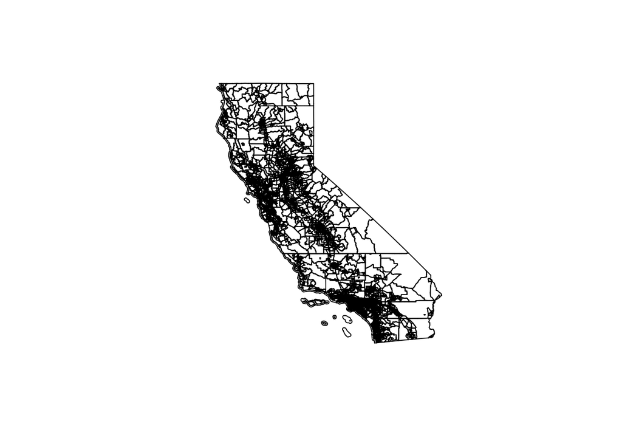

```r
plot(st_geometry(ca_bg))  # shows all polygons
```

How the TIGER/Line shapefile helps: TIGER/Line gives you polygons for every block group. Each polygon is a small area with a GEOID that can be matched to population or economic data from ACS. (a grid over California that tells you where people live.)

Now we can overlay census data to know roughly how many people were potentially affected in each of the top evacuation zones in California.

```r
library(tidycensus)

pop_ca_bg <- get_acs(
  geography = "block group",
  variables = "B01003_001",  # total population
  state = "CA",
  year = 2021,
  survey = "acs5",
  geometry = FALSE
)
# pop_ca_bg now has GEOID + total population (estimate)
head(pop_ca_bg)
```

```
## # A tibble: 6 × 5
##   GEOID        NAME                                      variable estimate   moe
##   <chr>        <chr>                                     <chr>       <dbl> <dbl>
## 1 060014001001 Block Group 1, Census Tract 4001, Alamed… B01003_…     1963   457
## 2 060014001002 Block Group 2, Census Tract 4001, Alamed… B01003_…     1361   273
## 3 060014002001 Block Group 1, Census Tract 4002, Alamed… B01003_…     1029   151
## 4 060014002002 Block Group 2, Census Tract 4002, Alamed… B01003_…     1009   214
## 5 060014003001 Block Group 1, Census Tract 4003, Alamed… B01003_…     1122   301
## 6 060014003002 Block Group 2, Census Tract 4003, Alamed… B01003_…     1623   397
```

```r
library(tidyverse)

# Make sure GEOID columns are character
ca_bg$GEOID <- as.character(ca_bg$GEOID)
pop_ca_bg$GEOID <- as.character(pop_ca_bg$GEOID)

# Join population
ca_bg_pop <- ca_bg %>%
  left_join(pop_ca_bg %>% select(GEOID, estimate), by = "GEOID")

# Check
head(ca_bg_pop)
```

```
## Simple feature collection with 6 features and 14 fields
## Geometry type: MULTIPOLYGON
## Dimension:     XY
## Bounding box:  xmin: -121.9039 ymin: 37.22778 xmax: -121.7988 ymax: 37.46804
## Geodetic CRS:  NAD83
##   STATEFP COUNTYFP TRACTCE BLKGRPCE        GEOID               GEOIDFQ
## 1      06      085  512056        1 060855120561 1500000US060855120561
## 2      06      085  503222        1 060855032221 1500000US060855032221
## 3      06      085  504424        3 060855044243 1500000US060855044243
## 4      06      085  512059        2 060855120592 1500000US060855120592
## 5      06      085  504002        3 060855040023 1500000US060855040023
## 6      06      085  503802        3 060855038023 1500000US060855038023
##        NAMELSAD MTFCC FUNCSTAT   ALAND AWATER    INTPTLAT     INTPTLON estimate
## 1 Block Group 1 G5030        S  630075      0 +37.2704528 -121.8076171     2748
## 2 Block Group 1 G5030        S  330743      0 +37.2964056 -121.8427665     3922
## 3 Block Group 3 G5030        S 1052711      0 +37.4575935 -121.8955805      988
## 4 Block Group 2 G5030        S  366606      0 +37.2318978 -121.8016962     1748
## 5 Block Group 3 G5030        S  373230      0 +37.3508523 -121.8317109     2514
## 6 Block Group 3 G5030        S  421521      0 +37.3888311 -121.8355612     1699
##                         geometry
## 1 MULTIPOLYGON (((-121.8142 3...
## 2 MULTIPOLYGON (((-121.8484 3...
## 3 MULTIPOLYGON (((-121.9039 3...
## 4 MULTIPOLYGON (((-121.8039 3...
## 5 MULTIPOLYGON (((-121.8368 3...
## 6 MULTIPOLYGON (((-121.8408 3...
```

```r
library(tidyverse)

# Assume these are your objects:
# ca_bg_pop -> block groups with population
# cali_longest_zones_sf -> evacuation zones polygons

# Make sure both have the same CRS
st_crs(cali_longest_zones_sf) <- st_crs(ca_bg_pop)
# Intersect block groups with evacuation zones
evac_pop_overlay <- st_intersection(
  cali_longest_zones_sf,
  ca_bg_pop
)
# Estimate population affected per zone
evac_population_summary <- evac_pop_overlay %>%
  group_by(display_name) %>%  # evacuation zone
  summarise(
    affected_population = sum(estimate, na.rm = TRUE)
  ) %>%
  arrange(desc(affected_population))

# Check results
evac_population_summary
```

```
## Simple feature collection with 18 features and 2 fields
## Geometry type: POLYGON
## Dimension:     XY
## Bounding box:  xmin: -123.3282 ymin: 34.56369 xmax: -118.6738 ymax: 41.93236
## Geodetic CRS:  NAD83
## # A tibble: 18 × 3
##    display_name      affected_population                                geometry
##    <chr>                           <dbl>                           <POLYGON [°]>
##  1 GOR-HUNGRYVALLEY                25803 ((-118.7531 34.64923, -118.7531 34.649…
##  2 CAS-PARADISERANCH               17733 ((-118.6839 34.5637, -118.6834 34.5637…
##  3 SIS-3315                        15580 ((-122.4772 41.87383, -122.477 41.8735…
##  4 SIS-3413                        12136 ((-122.4626 41.85739, -122.4572 41.856…
##  5 SIS-3312                         9102 ((-122.4967 41.88954, -122.497 41.8884…
##  6 SIS-3208                         8136 ((-122.464 41.9033, -122.4639 41.90336…
##  7 SIS-3211                         8136 ((-122.4637 41.90353, -122.4639 41.903…
##  8 SIS-3318                         7404 ((-122.411 41.88343, -122.4087 41.8844…
##  9 K31                              7362 ((-119.0053 36.86057, -119.0019 36.857…
## 10 K40                              6676 ((-119.2022 36.87382, -119.1971 36.874…
## 11 K41                              4842 ((-119.2417 36.8852, -119.24 36.88559,…
## 12 CCU-152-A                        4156 ((-120.6713 37.96216, -120.6764 37.977…
## 13 K166                             3652 ((-119.2451 36.96983, -119.2495 36.953…
## 14 K30                              3652 ((-119.1973 36.92898, -119.1932 36.929…
## 15 SIS-3416                         2806 ((-122.2796 41.75656, -122.2776 41.758…
## 16 K29                              2751 ((-119.1537 37.061, -119.1335 37.08359…
## 17 K76                              1818 ((-119.3134 36.91742, -119.3135 36.912…
## 18 SIS-1004                         1448 ((-123.241 41.86016, -123.2405 41.8601…
```

Now we can visualize it on a map using color to show higher/lower population affected, show community impact, and combine with evacuation duration to estimate the “Cumulative Population Exposure” metric as a measure of community burden.

```r
library(leaflet)

pal <- colorNumeric("YlOrRd", domain = evac_population_summary$affected_population)

leaflet(evac_population_summary) %>%
  addProviderTiles(providers$CartoDB.Positron) %>%
  addPolygons(
    fillColor = ~pal(affected_population),
    fillOpacity = 0.7,
    color = "#444",
    weight = 0.5,
    popup = ~paste0(display_name, "<br>Population: ", affected_population)
  ) %>%
  addLegend(
    pal = pal,
    values = ~affected_population,
    title = "Population Affected",
    opacity = 0.7
  )
```

```r
library(tidyverse)

# Join the population summary with evacuation duration
evac_impact <- evac_population_summary %>%
  left_join(
    cali_longest_zones_sf %>%
      st_drop_geometry() %>%
      select(display_name, duration_hours),
    by = "display_name"
  ) %>%
  mutate(
    cumulative_population_exposure = affected_population * duration_hours
  ) %>%
  arrange(desc(cumulative_population_exposure))
# View top impacted zones
head(evac_impact)
```

```
## Simple feature collection with 6 features and 5 fields
## Geometry type: POLYGON
## Dimension:     XY
## Bounding box:  xmin: -118.8946 ymin: 34.56369 xmax: -118.6738 ymax: 34.81789
## Geodetic CRS:  NAD83
## # A tibble: 6 × 6
##   display_name      affected_population                          geometry uid_v2
##   <chr>                           <dbl>                     <POLYGON [°]> <chr>
## 1 GOR-HUNGRYVALLEY                25803 ((-118.7531 34.64923, -118.7531 … los_a…
## 2 GOR-HUNGRYVALLEY                25803 ((-118.7531 34.64923, -118.7531 … los_a…
## 3 GOR-HUNGRYVALLEY                25803 ((-118.7531 34.64923, -118.7531 … los_a…
## 4 CAS-PARADISERANCH               17733 ((-118.6839 34.5637, -118.6834 3… los_a…
## 5 CAS-PARADISERANCH               17733 ((-118.6839 34.5637, -118.6834 3… los_a…
## 6 CAS-PARADISERANCH               17733 ((-118.6839 34.5637, -118.6834 3… los_a…
## # ℹ 2 more variables: duration_hours <dbl>,
## #   cumulative_population_exposure <dbl>
```

```r
library(leaflet)

# Define color palette based on evacuation duration
pal_duration <- colorNumeric("YlOrRd", domain = evac_impact$duration_hours)

leaflet(evac_impact) %>%
  addProviderTiles(providers$CartoDB.Positron) %>%
  addPolygons(
    fillColor = ~pal_duration(duration_hours),  # color by duration
    fillOpacity = 0.7,
    color = "#444",
    weight = 0.5,
    popup = ~paste0(
      "<b>Zone:</b> ", display_name, "<br>",
      "<b>Duration (hrs):</b> ", round(duration_hours, 1), "<br>",
      "<b>Population:</b> ", affected_population
    )
  ) %>%
  addLegend(
    pal = pal_duration,
    values = ~duration_hours,
    title = "Evacuation Duration (hrs)",
    opacity = 0.7
  )
```

This heatmap-style map where zones with high numbers of people and long durations stand out shows the community impact.

```r
library(tidyverse)

# Create summary table sorted by population affected
evac_summary_table <- evac_impact %>%
  st_drop_geometry() %>%  # remove geometry for table display
  select(
    Zone = display_name,
    Duration_Hours = duration_hours,
    Population_Affected = affected_population
  ) %>%
  arrange(desc(Population_Affected))  # sort by population descending

# View the table
evac_summary_table
```

[output not shown]

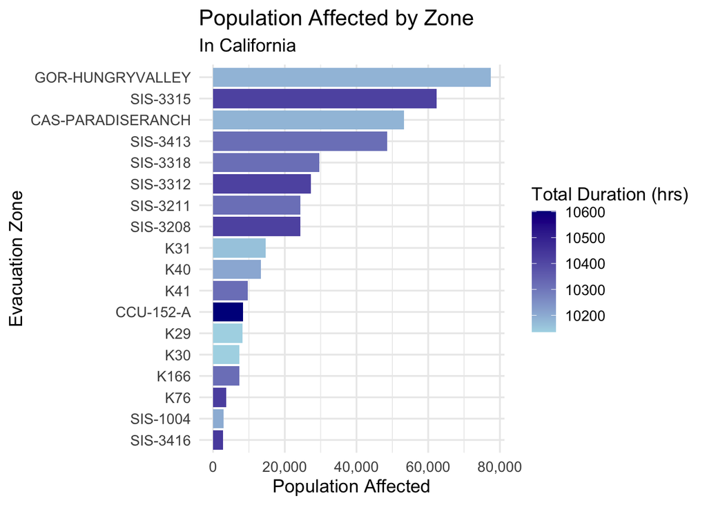

```r
library(ggplot2)
library(tidyverse)
library(scales)

# Summarize by zone first to remove duplicates
evac_summary <- evac_impact %>%
  group_by(display_name, duration_hours) %>%
  summarise(
    affected_population = sum(affected_population, na.rm = TRUE),
    .groups = "drop"
  ) %>%
  arrange(affected_population) %>%
  mutate(
    Zone_Label = factor(display_name, levels = display_name)
  )

# Plot
ggplot(evac_summary, aes(x = affected_population, y = Zone_Label, fill = duration_hours)) +
  geom_col() +
  scale_fill_gradient(low = "lightblue", high = "darkblue", name = "Total Duration (hrs)") +
  scale_x_continuous(labels = comma) +
  labs(
    title = "Population Affected by Zone",
    subtitle = "In California",
    x = "Population Affected",
    y = "Evacuation Zone"
  ) +
  theme_minimal(base_size = 13)
```

How much evacuation time does the average person in this zone experience?

```r
library(tidyverse)

california_evac_summary <- evac_impact %>%
  st_drop_geometry() %>%
  mutate(
    Evacuation_Duration_Per_Person = duration_hours / affected_population
  ) %>%
  select(
    Zone = display_name,
    Duration_Hours = duration_hours,
    Population_Affected = affected_population,
    Evacuation_Duration_Per_Person
  ) %>%
  arrange(desc(Evacuation_Duration_Per_Person))

# View table
california_evac_summary
```

```
## # A tibble: 47 × 4
##    Zone     Duration_Hours Population_Affected Evacuation_Duration_Per_Person
##    <chr>             <dbl>               <dbl>                          <dbl>
##  1 SIS-1004         10198.                1448                           7.04
##  2 SIS-1004         10198.                1448                           7.04
##  3 K76              10426.                1818                           5.73
##  4 K76              10426.                1818                           5.73
##  5 SIS-3416         10435.                2806                           3.72
##  6 K29              10136.                2751                           3.68
##  7 K29              10136.                2751                           3.68
##  8 K29              10136.                2751                           3.68
##  9 K166             10320.                3652                           2.83
## 10 K166             10320.                3652                           2.83
## # ℹ 37 more rows
```

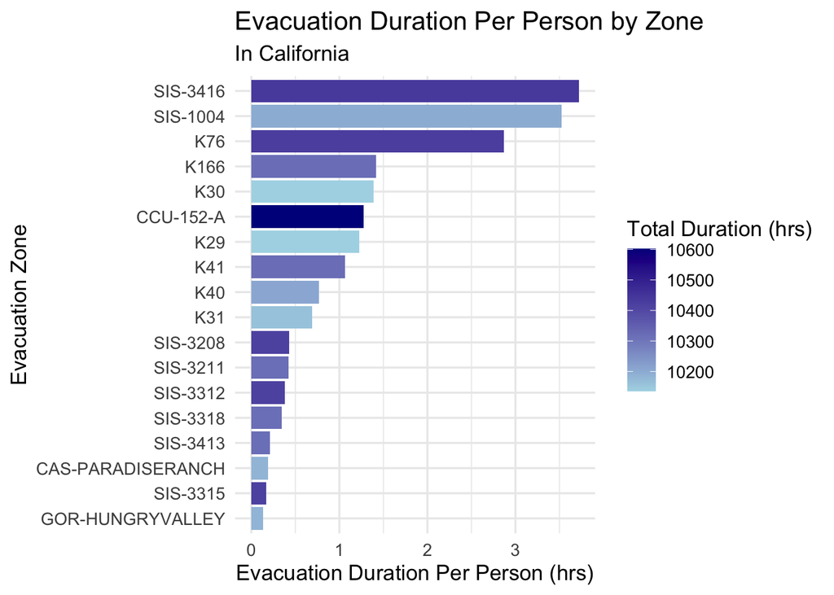

```r
library(ggplot2)
library(tidyverse)
library(scales)

# Summarize by zone
evac_summary <- evac_impact %>%
  group_by(display_name, duration_hours) %>%
  summarise(
    duration_hours = max(duration_hours, na.rm = TRUE), affected_population = sum(affected_population, na.rm = TRUE),
    .groups = "drop"
  ) %>%
  mutate(
    Evacuation_Duration_Per_Person = duration_hours / affected_population,
    Zone_Label = factor(display_name, levels = display_name[order(Evacuation_Duration_Per_Person)])
  )

# Plot
ggplot(evac_summary,
       aes(x = Evacuation_Duration_Per_Person,
           y = Zone_Label,
           fill = duration_hours)) +
  geom_col() +
  scale_fill_gradient(low = "lightblue", high = "darkblue", name = "Total Duration (hrs)") +
  scale_x_continuous(labels = comma) +
  labs(
    title = "Evacuation Duration Per Person by Zone",
    subtitle = "In California",
    x = "Evacuation Duration Per Person (hrs)",
    y = "Evacuation Zone"
  ) +
  theme_minimal(base_size = 13)
```

Next, the median household income for all California block groups was obtained from the U.S. Census site.

B19013_001E was being read as character, but we need it to be numeric for our calculations. Also, there were some NAs, so those were carefully removed.

Next, we need to link the cleaned ACS income data to the evacuation zones. To do this we will

1. Link ACS median income to each evacuation zone using block group polygons.
2. Aggregate income at the zone level (mean income of affect block groups).
3. Rank zones to see which communities are most economically affected.

```r
colnames(evac_zones_sf)
```

```
##  [1] "id"                 "date_created"       "date_modified"
##  [4] "uid_v2"             "is_active"          "display_name"
##  [7] "region_id"          "source_attribution" "dataset_name"
## [10] "source_extra_data"  "geometry"           "status"
## [13] "geom_label"         "is_pending_review"  "pending_updates"
## [16] "external_status"
```

```r
library(sf)
library(dplyr)
library(tidycensus)

# Step 1: Load CA block groups
ca_bg <- st_read("tl_2025_06_bg.shp")
```

```r
# Step 2: Transform to WGS84 (EPSG:4326)
ca_bg <- st_transform(ca_bg, 4326)

# Step 3: Pull median household income from ACS
acs_income <- get_acs(
  geography = "block group",
  variables = "B19013_001",
  state = "CA",
  year = 2021,
  survey = "acs5",
  geometry = FALSE
)
# Step 4: Clean ACS income
acs_income_clean <- acs_income %>%
  select(GEOID, median_income = estimate) %>%
  filter(!is.na(median_income)) %>%
  mutate(median_income = as.numeric(median_income))

# Step 5: Join ACS income to CA block groups
ca_bg$GEOID <- as.character(ca_bg$GEOID)
acs_income_clean$GEOID <- as.character(acs_income_clean$GEOID)

ca_bg_income <- ca_bg %>%
  left_join(acs_income_clean, by = "GEOID")

# Step 6: Transform evacuation zones to match CA block groups
cali_longest_zones_sf <- st_transform(cali_longest_zones_sf, st_crs(ca_bg_income))
```

st_transform() reprojects the polygons, converting coordinates so everything lines up properly on a map.

We queried the ACS 5-year survey for median household income for all block groups in California. We only kept the GEOID and renamed estimate as median_income. NAs were removed, and median_income was converted to numeric.

Income data was attached to each block group polygon by GEOID, and the evacuation zones were reprojected to match the CRS of the block groups.

Next, we will calculate the estimated median household income per evacuation zone and rank the zones based on their income.

```r
library(dplyr)
library(sf)

# --- Step 1: Ensure CRS matches (just in case) ---
ca_bg_income <- st_transform(ca_bg_income, st_crs(cali_longest_zones_sf))

# --- Step 2: Spatial join block groups to evacuation zones ---
evac_bg_join <- st_join(
  ca_bg_income,
  cali_longest_zones_sf %>% select(display_name, duration_hours),
  join = st_intersects,
  left = FALSE
)

# --- Step 3: Aggregate mean income per evacuation zone ---
zone_income <- evac_bg_join %>%
  group_by(display_name, duration_hours) %>%
  summarise(
    est_median_income = mean(median_income, na.rm = TRUE),
    .groups = "drop"
  )

# --- Step 4: Combine with population (from previous overlay) ---
zone_income_pop <- zone_income %>%
  st_drop_geometry() %>%  # drop geometry to join safely
  left_join(evac_population_summary, by = "display_name")  # includes affected_population

# --- Step 5: Compute Evacuation Duration Per Person ---
zone_income_pop <- zone_income_pop %>%
  mutate(
    Evacuation_Per_Person = duration_hours / affected_population
  )

# --- Step 6: Rank-based Economic Disruption Score ---
zone_income_pop <- zone_income_pop %>%
  mutate(
    # Rank zones: lower income → higher rank
    income_rank = rank(est_median_income, ties.method = "min"),
    income_rank_rev = max(income_rank) - income_rank + 1,

    # Rank zones by evacuation per person: higher = higher rank
    evac_rank = rank(Evacuation_Per_Person, ties.method = "min"),

    # Composite rank: sum of ranks
    econ_disruption_rank = income_rank_rev + evac_rank
  ) %>%
  arrange(desc(econ_disruption_rank))

# --- Step 7: View top 10 most economically disrupted zones ---
top_econ_zones <- zone_income_pop %>%
  select(
    Zone = display_name,
    Duration_Hours = duration_hours,
    Population_Affected = affected_population,
    Est_Median_Income = est_median_income,
    Evacuation_Per_Person,
    Income_Rank_Rev = income_rank_rev,
    Evac_Rank = evac_rank,
    Economic_Disruption_Rank = econ_disruption_rank
  )

top_econ_zones
```

```
## # A tibble: 18 × 8
##    Zone              Duration_Hours Population_Affected Est_Median_Income
##    <chr>                      <dbl>               <dbl>             <dbl>
##  1 SIS-1004                  10198.                1448            33266
##  2 SIS-3416                  10435.                2806            49048.
##  3 K41                       10320.                4842            43819
##  4 K31                       10161.                7362            42757.
##  5 K40                       10207.                6676            52014.
##  6 K29                       10136.                2751            60208
##  7 K166                      10320.                3652            60208
##  8 K30                       10136.                3652            60208
##  9 SIS-3208                  10417.                8136            53076.
## 10 SIS-3211                  10318.                8136            53076.
## 11 K76                       10426.                1818              NaN
## 12 SIS-3318                  10318.                7404            54189
## 13 CCU-152-A                 10602.                4156            98672.
## 14 SIS-3312                  10416.                9102            53803
## 15 SIS-3315                  10417.               15580            53190
## 16 SIS-3413                  10318.               12136            53803
## 17 GOR-HUNGRYVALLEY          10184.               25803            82143.
## 18 CAS-PARADISERANCH         10182.               17733           122694.
## # ℹ 4 more variables: Evacuation_Per_Person <dbl>, Income_Rank_Rev <dbl>,
## #   Evac_Rank <int>, Economic_Disruption_Rank <dbl>
```

**Est_Median_Income = Estimated Median Income (the mean of all overlapped median household incomes within the zones)

To assess the economic impact of evacuations, we calculated a composite Economic Disruption Rank for each evacuation zone by combining measures of economic vulnerability and evacuation burden. First, each zone was ranked by mean household income, with lower-income zones receiving higher scores to reflect greater economic vulnerability (Income_Rank_Rev). Next, we calculated the evacuation burden per person by dividing total evacuation duration by the affected population, and ranked zones so that higher burdens corresponded to higher ranks (Evac_Rank). Finally, the Economic Disruption Rank was computed as the sum of these two ranks, identifying zones that simultaneously experience longer evacuations per person and greater economic vulnerability. This rank-based approach provides an intuitive measure of which communities are most economically disrupted, while minimizing the influence of extreme values and differing units across the underlying metrics.

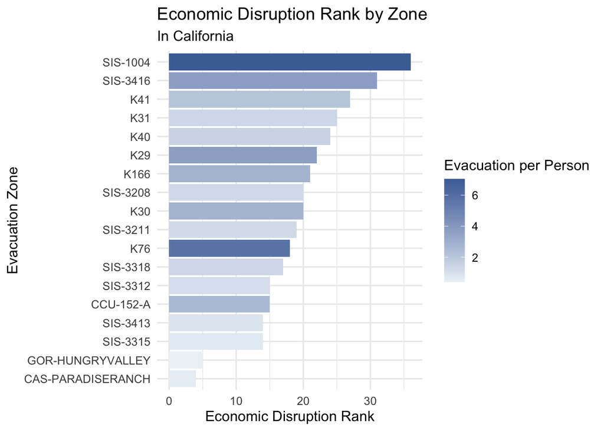

```r
library(ggplot2)
library(scales)
library(dplyr)

# Arrange zones by rank for plotting
zone_plot_data <- zone_income_pop %>%
  arrange((econ_disruption_rank)) %>%
  mutate(Zone_Label = factor(display_name, levels = display_name))

# Horizontal bar chart
ggplot(zone_plot_data, aes(x = econ_disruption_rank, y = Zone_Label, fill = Evacuation_Per_Person)) +
  geom_col() +
  scale_fill_gradient(low = "#EDF3F7", high = "#4A6FA5", name = "Evacuation per Person") +
  scale_x_continuous(labels = comma) +
  labs(
    title = "Economic Disruption Rank by Zone",
    subtitle = "In California",
    x = "Economic Disruption Rank",
    y = "Evacuation Zone"
  ) +
  theme_minimal(base_size = 12)
```

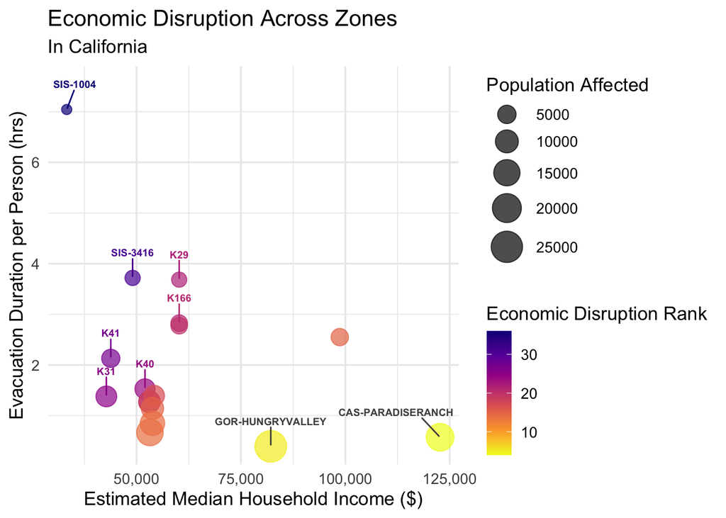

```r
library(ggplot2)
library(ggrepel)
library(scales)

# Identify top 7 zones
top7_zones <- zone_income_pop %>%
  slice_max(econ_disruption_rank, n = 7)

# Identify two lowest zones
bottom2_zones <- zone_income_pop %>%
  slice_min(econ_disruption_rank, n=2)

# Scatterplot with labels for top 3 zones
ggplot(zone_income_pop,
       aes(x = est_median_income,
           y = Evacuation_Per_Person,
           size = affected_population,
           color = econ_disruption_rank)) +
  geom_point(alpha = 0.7) +

  # Labels for highest disruption
  geom_text_repel(
    data = top7_zones,
    aes(label = display_name),
    size = 2.5,
    fontface = "bold",
    nudge_y = 0.5
  ) +

    # Labels for lowest disruption (yellow dots)
  geom_text_repel(
    data = bottom2_zones,
    aes(label = display_name),
    size = 2.5,
    fontface = "bold",
    nudge_y = 0.5,
    color = "gray30"
  ) +

  scale_size(range = c(3, 10), name = "Population Affected") +
  scale_color_viridis_c(option = "plasma", direction = -1, name = "Economic Disruption Rank") +
  scale_x_continuous(labels = comma) +
  labs(
    title = "Economic Disruption Across Zones",
    subtitle = "In California",
    x = "Estimated Median Household Income ($)",
    y = "Evacuation Duration per Person (hrs)",
  ) +
  theme_minimal(base_size = 13)
```

Next, we will bring in C17002 - Ratio of Income to Poverty Level in the Past 12 Months ACS 2024 from the US Census.

Poverty captures vulnerability better than income alone. Poverty rate directly measures households with limited savings, greater likelihood of income shocks, lower ability to evacuate or recover, and greater dependence on public assistance.

I want to combine the poverty rate and median income data to truly capture the evacuation burden per person.

```r
poverty_raw <- read_csv("ACSDT5Y2024.C17002-Data.csv")
```

```
## ──────────────────────────────────────────────────────── Delimiter: "," chr
## (18): GEO_ID, NAME, C17002_001E, C17002_001M, C17002_002E, C17002_002M, ... lgl
## (1): ...19
```

```r
colnames(poverty_raw)
```

```
##  [1] "GEO_ID"      "NAME"        "C17002_001E" "C17002_001M" "C17002_002E"
##  [6] "C17002_002M" "C17002_003E" "C17002_003M" "C17002_004E" "C17002_004M"
## [11] "C17002_005E" "C17002_005M" "C17002_006E" "C17002_006M" "C17002_007E"
## [16] "C17002_007M" "C17002_008E" "C17002_008M" "...19"
```

```r
library(dplyr)

poverty_clean <- poverty_raw %>%
  select(
    GEOID = GEO_ID,
    total_pop = C17002_001E,
    below_50 = C17002_002E,
    below_100 = C17002_003E
  ) %>%
  mutate(
    GEOID = substr(GEOID, 10, 21),
    total_pop = as.numeric(total_pop),
    below_50 = as.numeric(below_50),
    below_100 = as.numeric(below_100),
    below_poverty = below_50 + below_100,
    poverty_rate = below_poverty / total_pop
  ) %>%
  filter(!is.na(poverty_rate))
ca_bg$GEOID <- as.character(ca_bg$GEOID)
poverty_clean$GEOID <- as.character(poverty_clean$GEOID)

ca_bg_poverty <- ca_bg %>%
  left_join(poverty_clean, by = "GEOID")
```

```r
evac_poverty_join <- st_join(
  ca_bg_poverty,
  cali_longest_zones_sf,
  join = st_intersects,
  left = FALSE
)

zone_poverty <- evac_poverty_join %>%
  group_by(display_name) %>%
  summarise(
    poverty_rate = weighted.mean(poverty_rate, total_pop, na.rm = TRUE)
  )
```

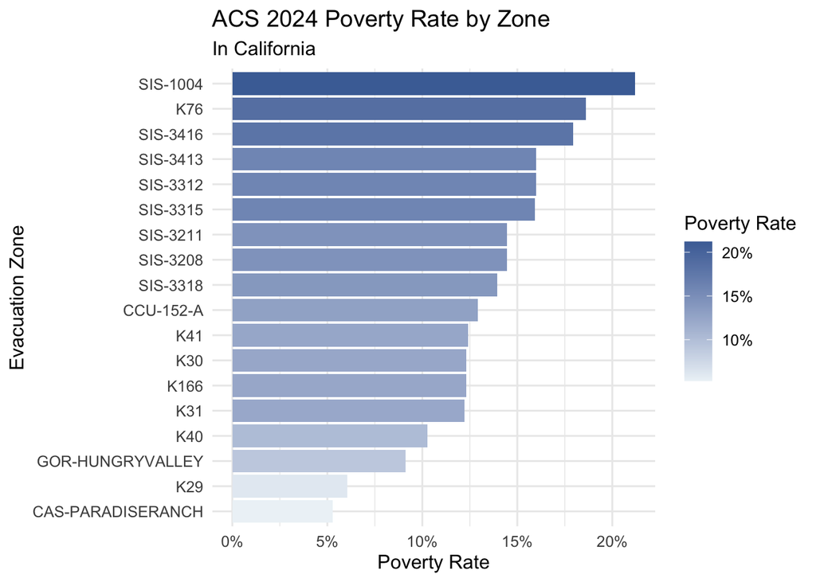

```r
library(ggplot2)
library(scales)
library(dplyr)

# Arrange zones by poverty rate
zone_plot_poverty <- zone_poverty %>%
  arrange(poverty_rate) %>%
  mutate(Zone_Label = factor(display_name, levels = display_name))

# Horizontal bar chart
ggplot(zone_plot_poverty,
       aes(x = poverty_rate,
           y = Zone_Label,
           fill = poverty_rate)) +
  geom_col() +
  scale_fill_gradient(
    low = "#EDF3F7",
    high = "#4A6FA5",
    labels = percent_format(accuracy = 1),
    name = "Poverty Rate"
  ) +
  scale_x_continuous(labels = percent_format(accuracy = 1)) +
  labs(
    title = "ACS 2024 Poverty Rate by Zone",
    subtitle = "In California",
    x = "Poverty Rate",
    y = "Evacuation Zone"
  ) +
  theme_minimal(base_size = 12)
```

```r
summary(zone_poverty$poverty_rate)
```

```
##    Min. 1st Qu.  Median    Mean 3rd Qu.    Max.
## 0.05283 0.12239 0.13433 0.13412 0.15978 0.21203
```

To estimate poverty at the evacuation zone level, I aggregated Census block group data using a population-weighted mean rather than a simple average. Each block group has its own poverty rate and total population, and evacuation zones often intersect multiple block groups of very different sizes. A simple arithmetic mean would treat each block group equally regardless of whether it contains 300 residents or 5,000 residents, which could substantially distort the estimate. Instead, I calculated a weighted mean in which each block group’s poverty rate is multiplied by its total population, summed across all intersecting block groups, and then divided by the total population within the evacuation zone. Mathematically, this is expressed as the sum of (poverty_rate × population) divided by the sum of population. This approach ensures that larger population centers contribute proportionally more to the zone-level estimate, meaning the final value represents the share of people—rather than the share of spatial units—living below the poverty threshold within each evacuation zone. Using population-weighted aggregation aligns the measure with the study’s focus on human vulnerability and economic resilience, and avoids biases introduced by uneven census geography.

```r
zone_poverty <- zone_poverty %>%
  st_drop_geometry()

zone_map <- cali_longest_zones_sf %>%
  left_join(zone_poverty, by = "display_name")

library(leaflet)
library(scales)

pal <- colorNumeric(
  palette = "Blues",
  domain = zone_map$poverty_rate,
  na.color = "transparent"
)

leaflet(zone_map) %>%
  addProviderTiles("CartoDB.Positron") %>%
  addPolygons(
    fillColor = ~pal(poverty_rate),
    weight = 1,
    color = "white",
    fillOpacity = 0.8,
    popup = ~paste0(
      "<strong>Zone:</strong> ", display_name,
      "<br><strong>Poverty Rate:</strong> ",
      percent(poverty_rate, accuracy = 0.1)
    )
  ) %>%
  addLegend(
    pal = pal,
    values = ~poverty_rate,
    labFormat = labelFormat(suffix = "%", transform = function(x) x * 100),
    title = "Poverty Rate",
    position = "bottomright"
  )
```

[interactive chart not shown]